# **1. About Dataset:**

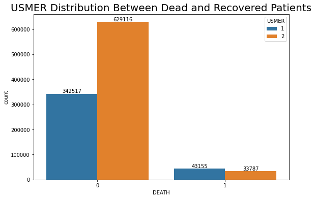

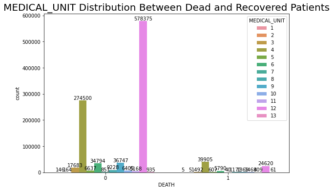

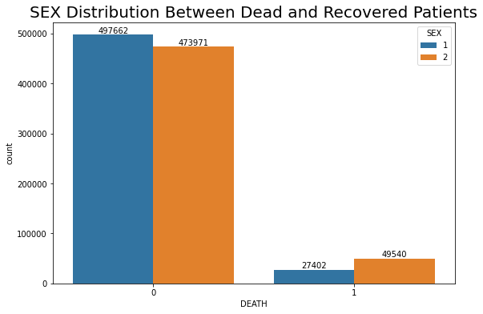

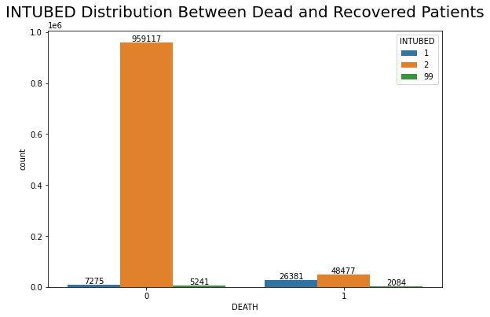

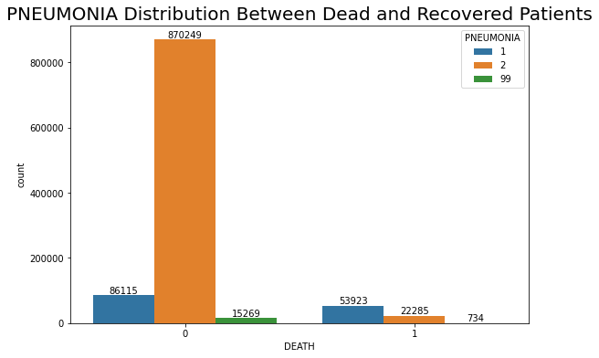

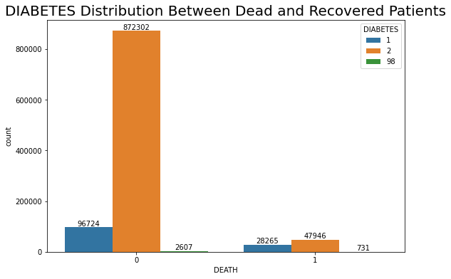

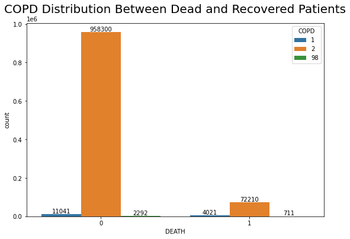

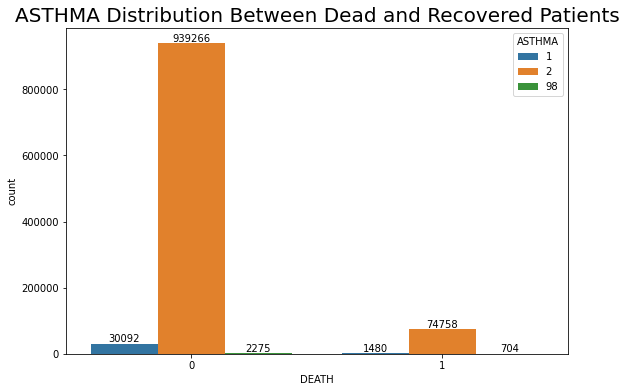

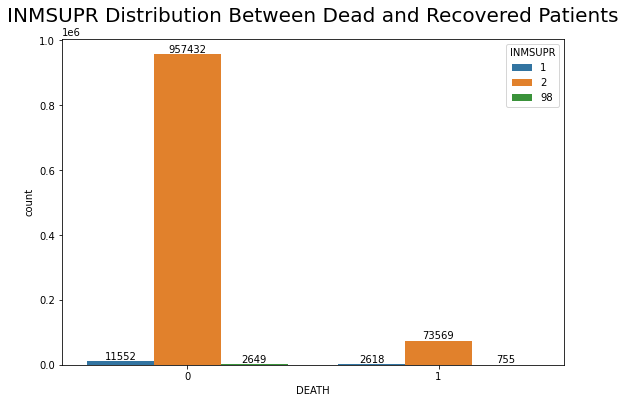

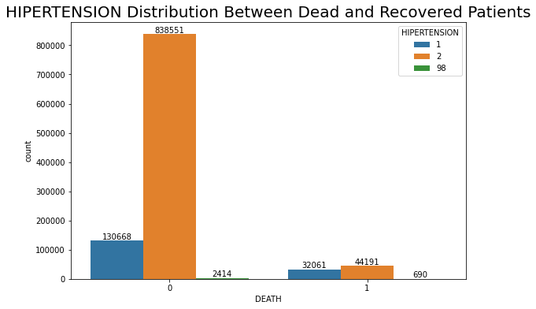

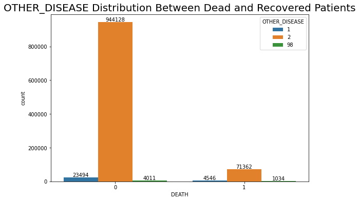

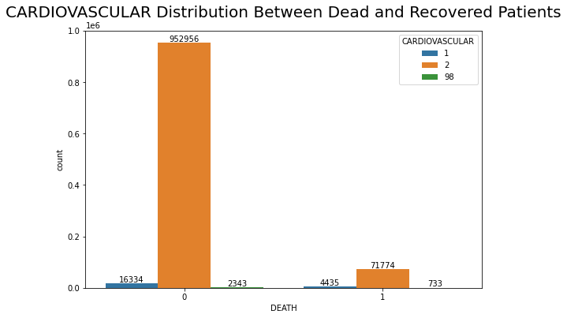

[7 more figures not shown]

```python
# Show the distrubution of different features between dead and recovered patients.

for column in selected_columns:

  plt.figure(figsize = (9,6))
  ax = sns.countplot(df.DEATH, hue = df[column])
  for bars in ax.containers:
      ax.bar_label(bars)


  plt.title(str(column) + ' Distribution Between Dead and Recovered Patients', fontsize = 20);
  plt.show()
```

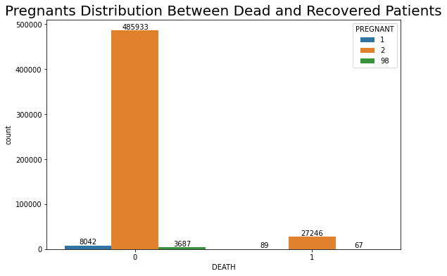

```python
# Show the distrubution of pregnants and non-pregnants women between dead and recovered patient


plt.figure(figsize = (9,6))
ax = sns.countplot(df_female.DEATH, hue = df_female.PREGNANT)
for bars in ax.containers:
    ax.bar_label(bars)


plt.title( 'Pregnants Distribution Between Dead and Recovered Patients', fontsize = 20);
plt.show()
```

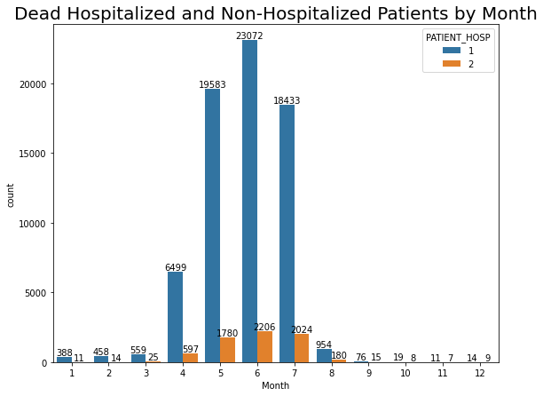

```python
# Plotting of Dead Hospitalized and Non-Hospitalized Patients by Month

plt.figure(figsize = (9,7))
ax = sns.countplot(x = "Month", hue = "PATIENT_HOSP", data = df_death)
plt.title("Dead Hospitalized and Non-Hospitalized Patients by Month", fontsize = 20)
for bars in ax.containers:
    ax.bar_label(bars)
```

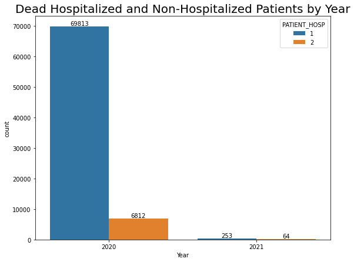

```python
# Plotting of Dead Hospitalized and Non-Hospitalized Patients by Year

plt.figure(figsize = (9,7))
ax = sns.countplot(x = "Year", hue = "PATIENT_HOSP", data = df_death)
plt.title("Dead Hospitalized and Non-Hospitalized Patients by Year", fontsize = 20)
for bars in ax.containers:
    ax.bar_label(bars)
```

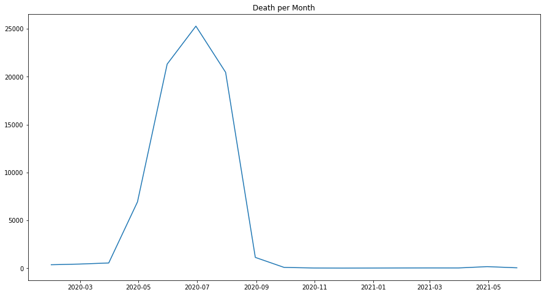

```python
# Death by time

time_data = df_death.resample('M', on = time_col)['DEATH'].count().fillna(0)

fig, ax = plt.subplots(figsize = (15,8))
ax.plot(time_data)
plt.title('Death per Month');
```

**- Dealing with (Medical_UNIT) Feature:**

- It seems that most people are in 12 or 4 type of medical units, may be they are the most available in Mexico.
- As long as we don't have any knowledge about these different types, we can't just combine them into 2 categories ex. (from 1 - 6) and from( 7-13)
- We don't think it's of clinical importance in identifieng the patient risk.
- We also have data on (usmr) whivch indicates Whether the patient treated medical units of the first, second or third level.
- Having dummies for 13 extra columns of Medical Units for around 1 M data points makes our data unable to be processed.
- So we will drop medical unit

```python
df.MEDICAL_UNIT.value_counts()
```

```
12    602995
4     314405
6      40584
9      38116
3      19175
8      10399
10      7873
5       7244
11      5577
13       996
7        891
2        169
1        151
Name: MEDICAL_UNIT, dtype: int64
```

```python
df.drop('MEDICAL_UNIT', axis = 1, inplace = True)
```

# **5. Pre-processing:**

```python
df.columns
```

```
Index(['USMER', 'SEX', 'INTUBED', 'PNEUMONIA', 'AGE', 'PREGNANT', 'DIABETES',
       'COPD', 'ASTHMA', 'INMSUPR', 'HIPERTENSION', 'OTHER_DISEASE',
       'CARDIOVASCULAR', 'OBESITY', 'RENAL_CHRONIC', 'TOBACCO',
       'CLASIFFICATION_FINAL', 'ICU', 'PATIENT_HOSP', 'COVID', 'DEATH'],
      dtype='object')
```

```python
# Specifying X and Y

X = df.drop(['DEATH','COVID'],axis =1)
y= df['DEATH']
```

```python
# Split into test and train data

from sklearn.model_selection import train_test_split

X_train, X_test, y_train, y_test = train_test_split(X, y, test_size=0.2, random_state= 1)
```

```python
#check the shape

X_train.shape, X_test.shape
```

```
((838860, 19), (209715, 19))
```

```python
# Imputing missing data with mode
# Imputing test dataset with mode of train dataset to avoid overfitting
```

Features with null values:

- Pneumonia: 99 = 16003
- Diabetes: 98 = 3338
- Copd: 98 = 3003
- Asthma: 98 = 2979
- Inmsupr: 98 = 3404
- Hypertension: 98 = 3104
- Cardiovascular: 98 = 3076
- Renal chronic: 98 = 3006
- Other disease: 98 = 5045
- Obesity: 98 = 3032
- Tobacco: 98 = 3220
- Pregnancy: 98 = 3754
- Intubed: 99 = 7325
- ICU: 99 = 7488

```python
# Check count values before and after imputation
X_train.PNEUMONIA.value_counts()
```

```
2     714099
1     111975
99     12786
Name: PNEUMONIA, dtype: int64
```

```python
# Imputation of train dataset (No null values in y (Death))
# Don't impute AGE beacause we don't want to drop age = 99 or 98 as this is not null in AGE


selected_columns = X_train.columns.drop('AGE')

for column in selected_columns:
    X_train[column].replace(98, np.nan, inplace = True)
    X_train[column].replace(99, np.nan, inplace = True)
    X_test[column].replace(98, np.nan, inplace = True)
    X_test[column].replace(99, np.nan, inplace = True)
```

```python
X_train.isnull().sum()
```

```
USMER                       0
SEX                         0
INTUBED                  5854
PNEUMONIA               12786
AGE                         0
PREGNANT                 2994
DIABETES                 2671
COPD                     2401
ASTHMA                   2389
INMSUPR                  2732
HIPERTENSION             2473
OTHER_DISEASE            4063
CARDIOVASCULAR           2468
OBESITY                  2417
RENAL_CHRONIC            2408
TOBACCO                  2577
CLASIFFICATION_FINAL        0
ICU                      5985
PATIENT_HOSP                0
dtype: int64
```

```python
X_test.isnull().sum()
```

```
USMER                      0
SEX                        0
INTUBED                 1471
PNEUMONIA               3217
AGE                        0
PREGNANT                 760
DIABETES                 667
COPD                     602
ASTHMA                   590
INMSUPR                  672
HIPERTENSION             631
OTHER_DISEASE            982
CARDIOVASCULAR           608
OBESITY                  615
RENAL_CHRONIC            598
TOBACCO                  643
CLASIFFICATION_FINAL       0
ICU                     1503
PATIENT_HOSP               0
dtype: int64
```

```python
#Imputation of train dataset (No null values in y (Death))

for column in X_train.columns:
  X_train[column].fillna(X_train[column].mode()[0], inplace=True)
```

```python
#Imputation of test dataset (No null values in y (Death))

for column in X_test.columns:
  X_test[column].fillna(X_train[column].mode()[0], inplace=True)
```

```python
X_train.isnull().sum()
```

```
USMER                   0
SEX                     0
INTUBED                 0
PNEUMONIA               0
AGE                     0
PREGNANT                0
DIABETES                0
COPD                    0
ASTHMA                  0
INMSUPR                 0
HIPERTENSION            0
OTHER_DISEASE           0
CARDIOVASCULAR          0
OBESITY                 0
RENAL_CHRONIC           0
TOBACCO                 0
CLASIFFICATION_FINAL    0
ICU                     0
PATIENT_HOSP            0
dtype: int64
```

```python
X_test.isnull().sum()
```

```
USMER                   0
SEX                     0
INTUBED                 0
PNEUMONIA               0
AGE                     0
PREGNANT                0
DIABETES                0
COPD                    0
ASTHMA                  0
INMSUPR                 0
HIPERTENSION            0
OTHER_DISEASE           0
CARDIOVASCULAR          0
OBESITY                 0
RENAL_CHRONIC           0
TOBACCO                 0
CLASIFFICATION_FINAL    0
ICU                     0
PATIENT_HOSP            0
dtype: int64
```

```python
# Check count values before and after imputation
X_train.PNEUMONIA.value_counts()
```

```
2.0    726885
1.0    111975
Name: PNEUMONIA, dtype: int64
```

```python
# Ensure imputation
# All categories must show 2 unique values except CLASSIFICATION_FINAL, MEDICAL_UNIT

# Check Cardinality in Categorical Features

selected_columns = X_train.columns.drop(['AGE'])

unique_dic = []

for col in selected_columns:

  unique_num_train = len(X_train[col].unique())
  unique_num_test = len(X_test[col].unique())
  unique_dic.append({'Total_Unique_Train' : unique_num_train,
                     'Total_Unique_Test' : unique_num_test })

unique_df = pd.DataFrame(unique_dic, index = selected_columns).sort_values(by = 'Total_Unique_Train', ascending = False)
unique_df
```

|  | Total_Unique_Train | Total_Unique_Test |
| --- | --- | --- |
| CLASIFFICATION_FINAL | 4 | 4 |
| USMER | 2 | 2 |
| SEX | 2 | 2 |
| ICU | 2 | 2 |
| TOBACCO | 2 | 2 |
| RENAL_CHRONIC | 2 | 2 |
| OBESITY | 2 | 2 |
| CARDIOVASCULAR | 2 | 2 |
| OTHER_DISEASE | 2 | 2 |
| HIPERTENSION | 2 | 2 |
| INMSUPR | 2 | 2 |
| ASTHMA | 2 | 2 |
| COPD | 2 | 2 |
| DIABETES | 2 | 2 |
| PREGNANT | 2 | 2 |
| PNEUMONIA | 2 | 2 |
| INTUBED | 2 | 2 |
| PATIENT_HOSP | 2 | 2 |

```python
# !pip install imblearn
```

```python
# from imblearn.under_sampling import NearMiss
# nr = NearMiss()

# X_train, y_train = nr.fit_resample(X_train, y_train)
```

```python
# Use  SMOTE (synthetic minority oversampling technique)

# from imblearn.over_sampling import SMOTE
# sm = SMOTE()
# X_train, y_train = sm.fit_resample(X_train, y_train)

# MemoryError: Unable to allocate 68.5 GiB for an array with shape (47277, 1554690) and data type uint8
```

```python
# Get dummies dataframe for categorical data

numerical_train = X_train[['AGE']]
ordinal_train = X_train[['CLASIFFICATION_FINAL','USMER']]
categorical_train = X_train.drop(['AGE', 'CLASIFFICATION_FINAL','USMER'], axis = 1)
```

```python
# Get dummies dataframe for categorical data

dummies_list = []

for column in categorical_train.columns:
  col_dummies = pd.get_dummies(X_train[column], drop_first = True)
  dummies_list.append(col_dummies)

dummies_df = pd.concat(dummies_list, axis=1)
```

```python
dummies_df
```

|  | 2.0 | 2.0 | 2.0 | 2.0 | 2.0 | 2.0 | 2.0 | 2.0 | 2.0 | 2.0 | 2.0 | 2.0 | 2.0 | 2.0 | 2.0 | 2.0 |
| --- | --- | --- | --- | --- | --- | --- | --- | --- | --- | --- | --- | --- | --- | --- | --- | --- |
| 656253 | 1 | 1 | 0 | 1 | 1 | 1 | 1 | 1 | 1 | 1 | 1 | 1 | 1 | 1 | 1 | 0 |
| 329191 | 0 | 1 | 1 | 1 | 1 | 1 | 1 | 1 | 1 | 1 | 1 | 0 | 1 | 1 | 1 | 1 |
| 557768 | 1 | 1 | 1 | 1 | 1 | 1 | 1 | 1 | 1 | 1 | 1 | 1 | 1 | 1 | 1 | 1 |
| 93060 | 1 | 1 | 1 | 1 | 1 | 1 | 1 | 1 | 1 | 1 | 1 | 1 | 1 | 1 | 1 | 1 |
| 558339 | 0 | 1 | 1 | 1 | 1 | 1 | 1 | 1 | 1 | 1 | 1 | 1 | 1 | 1 | 1 | 1 |
| ... | ... | ... | ... | ... | ... | ... | ... | ... | ... | ... | ... | ... | ... | ... | ... | ... |
| 491263 | 0 | 1 | 1 | 1 | 1 | 1 | 1 | 1 | 1 | 1 | 1 | 1 | 1 | 1 | 1 | 1 |
| 791624 | 0 | 1 | 1 | 1 | 1 | 1 | 1 | 1 | 0 | 1 | 1 | 0 | 1 | 1 | 1 | 1 |
| 470924 | 0 | 1 | 1 | 1 | 1 | 1 | 1 | 1 | 1 | 1 | 1 | 1 | 1 | 1 | 1 | 1 |
| 491755 | 1 | 1 | 1 | 1 | 1 | 1 | 1 | 1 | 1 | 1 | 1 | 1 | 1 | 1 | 1 | 1 |
| 128037 | 0 | 1 | 1 | 1 | 1 | 1 | 1 | 1 | 0 | 1 | 1 | 1 | 1 | 1 | 1 | 1 |

838860 rows × 16 columns

```python
#Get dataframe for other features
num_ord_df = pd.concat([numerical_train, ordinal_train], axis =1)
```

```python
num_ord_df
```

|  | AGE | CLASIFFICATION_FINAL | USMER |
| --- | --- | --- | --- |
| 656253 | 59 | 3 | 1 |
| 329191 | 25 | 0 | 2 |
| 557768 | 37 | 3 | 1 |
| 93060 | 25 | 3 | 2 |
| 558339 | 34 | 3 | 2 |
| ... | ... | ... | ... |
| 491263 | 63 | 3 | 2 |
| 791624 | 46 | 0 | 2 |
| 470924 | 57 | 1 | 2 |
| 491755 | 30 | 3 | 2 |
| 128037 | 46 | 3 | 2 |

838860 rows × 3 columns

```python
# # Add all features back to X_train
X_train = pd.merge(num_ord_df, dummies_df, left_index=True, right_index=True)

X_train
```

|  | AGE | CLASIFFICATION_FINAL | USMER | 2.0 | 2.0 | 2.0 | 2.0 | 2.0 | 2.0 | 2.0 | 2.0 | 2.0 | 2.0 | 2.0 | 2.0 | 2.0 | 2.0 | 2.0 | 2.0 |
| --- | --- | --- | --- | --- | --- | --- | --- | --- | --- | --- | --- | --- | --- | --- | --- | --- | --- | --- | --- |
| 656253 | 59 | 3 | 1 | 1 | 1 | 0 | 1 | 1 | 1 | 1 | 1 | 1 | 1 | 1 | 1 | 1 | 1 | 1 | 0 |
| 329191 | 25 | 0 | 2 | 0 | 1 | 1 | 1 | 1 | 1 | 1 | 1 | 1 | 1 | 1 | 0 | 1 | 1 | 1 | 1 |
| 557768 | 37 | 3 | 1 | 1 | 1 | 1 | 1 | 1 | 1 | 1 | 1 | 1 | 1 | 1 | 1 | 1 | 1 | 1 | 1 |
| 93060 | 25 | 3 | 2 | 1 | 1 | 1 | 1 | 1 | 1 | 1 | 1 | 1 | 1 | 1 | 1 | 1 | 1 | 1 | 1 |
| 558339 | 34 | 3 | 2 | 0 | 1 | 1 | 1 | 1 | 1 | 1 | 1 | 1 | 1 | 1 | 1 | 1 | 1 | 1 | 1 |
| ... | ... | ... | ... | ... | ... | ... | ... | ... | ... | ... | ... | ... | ... | ... | ... | ... | ... | ... | ... |
| 491263 | 63 | 3 | 2 | 0 | 1 | 1 | 1 | 1 | 1 | 1 | 1 | 1 | 1 | 1 | 1 | 1 | 1 | 1 | 1 |
| 791624 | 46 | 0 | 2 | 0 | 1 | 1 | 1 | 1 | 1 | 1 | 1 | 0 | 1 | 1 | 0 | 1 | 1 | 1 | 1 |
| 470924 | 57 | 1 | 2 | 0 | 1 | 1 | 1 | 1 | 1 | 1 | 1 | 1 | 1 | 1 | 1 | 1 | 1 | 1 | 1 |
| 491755 | 30 | 3 | 2 | 1 | 1 | 1 | 1 | 1 | 1 | 1 | 1 | 1 | 1 | 1 | 1 | 1 | 1 | 1 | 1 |
| 128037 | 46 | 3 | 2 | 0 | 1 | 1 | 1 | 1 | 1 | 1 | 1 | 0 | 1 | 1 | 1 | 1 | 1 | 1 | 1 |

838860 rows × 19 columns

```python
# Same steps for X_test

numerical_test = X_test[['AGE']]
ordinal_test = X_test[['CLASIFFICATION_FINAL','USMER']]
categorical_test = X_test.drop(['AGE', 'CLASIFFICATION_FINAL','USMER'], axis = 1)
```

```python
# Get dummies dataframe for categorical data

dummies_list_test = []

for column in categorical_test.columns:
  col_dummies = pd.get_dummies(X_test[column], drop_first = True)
  dummies_list_test.append(col_dummies)

dummies_df_test = pd.concat(dummies_list_test, axis=1)
```

```python
# Get dataframe for other features
num_ord_df_test = pd.concat([numerical_test, ordinal_test], axis =1)
```

```python
# Add all features back to X_train
X_test = pd.merge(num_ord_df_test, dummies_df_test, left_index=True, right_index=True)

X_test
```

|  | AGE | CLASIFFICATION_FINAL | USMER | 2.0 | 2.0 | 2.0 | 2.0 | 2.0 | 2.0 | 2.0 | 2.0 | 2.0 | 2.0 | 2.0 | 2.0 | 2.0 | 2.0 | 2.0 | 2.0 |
| --- | --- | --- | --- | --- | --- | --- | --- | --- | --- | --- | --- | --- | --- | --- | --- | --- | --- | --- | --- |
| 1045953 | 46 | 0 | 2 | 1 | 1 | 1 | 1 | 1 | 1 | 1 | 1 | 1 | 1 | 1 | 1 | 1 | 1 | 1 | 1 |
| 358409 | 35 | 3 | 1 | 0 | 1 | 1 | 1 | 1 | 1 | 1 | 1 | 1 | 1 | 1 | 1 | 1 | 1 | 1 | 1 |
| 875012 | 36 | 0 | 2 | 1 | 1 | 1 | 1 | 1 | 1 | 1 | 1 | 0 | 1 | 1 | 1 | 1 | 1 | 1 | 1 |
| 555046 | 27 | 3 | 2 | 1 | 1 | 1 | 1 | 1 | 1 | 1 | 1 | 1 | 1 | 1 | 1 | 1 | 1 | 1 | 1 |
| 272972 | 22 | 0 | 1 | 1 | 1 | 1 | 1 | 1 | 1 | 1 | 1 | 1 | 1 | 1 | 1 | 1 | 1 | 1 | 1 |
| ... | ... | ... | ... | ... | ... | ... | ... | ... | ... | ... | ... | ... | ... | ... | ... | ... | ... | ... | ... |
| 181305 | 30 | 0 | 2 | 1 | 1 | 1 | 1 | 1 | 1 | 1 | 1 | 1 | 1 | 1 | 1 | 1 | 1 | 1 | 1 |
| 672605 | 29 | 0 | 2 | 0 | 1 | 1 | 1 | 1 | 1 | 1 | 1 | 1 | 1 | 1 | 1 | 1 | 1 | 1 | 1 |
| 718823 | 68 | 0 | 1 | 0 | 1 | 1 | 1 | 1 | 1 | 1 | 1 | 1 | 1 | 1 | 1 | 1 | 1 | 1 | 1 |
| 1006146 | 54 | 0 | 2 | 1 | 1 | 1 | 1 | 1 | 1 | 1 | 1 | 1 | 1 | 1 | 1 | 1 | 1 | 1 | 1 |
| 23489 | 76 | 3 | 2 | 1 | 0 | 1 | 1 | 1 | 1 | 1 | 1 | 1 | 1 | 1 | 1 | 1 | 1 | 1 | 0 |

209715 rows × 19 columns

# **6. Logistic Regression**

## **i. Model Training**

```python
# Model training
# we will use solver = saga as we have a large dataset
from sklearn.linear_model import LogisticRegression

logreg = LogisticRegression(solver='saga', random_state=0)

logreg.fit(X_train, y_train)
```

```
LogisticRegression(random_state=0, solver='saga')
```

```python
#test data
y_pred_test = logreg.predict(X_test)
y_pred_train = logreg.predict(X_train)
```

## **ii. Validation Metrics**

### **a. Accuracy**

```python
#check for accuracy

from sklearn.metrics import accuracy_score

print('Model accuracy score(test): ', accuracy_score(y_test, y_pred_test))
print('Model accuracy score(train): ', accuracy_score(y_train, y_pred_train))
```

```
Model accuracy score(test):  0.9472951386405359
Model accuracy score(train):  0.9471890422716543
```

### **b. Null Accuracy**

```python
y_test.value_counts()
```

```
0    194288
1     15427
Name: DEATH, dtype: int64
```

```python
null_acuracy = 194288/(len(y_test))
null_acuracy
```

```
0.9264382614500631
```

```python
# null accuracy is less than our actual accuracy, hence, our model is not just predicting
# the most frequent value
```

### **c. Confusion Matrix**

```python
from sklearn.metrics import confusion_matrix
cm =confusion_matrix(y_test, y_pred_test)
```

```python
print('True Negatives (TN) = ', cm[0,0])
print('False Positives (FP)= ', cm[0, 1])
print('False Negatives (FN)= ', cm[1, 0])
print('True Positives (TP))= ', cm[1, 1])
```

[output not shown]

```python
# Visualze with heatmap
from sklearn.metrics import ConfusionMatrixDisplay
disp = ConfusionMatrixDisplay(confusion_matrix=cm, display_labels=logreg.classes_)
```

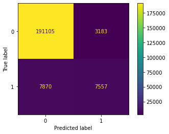

```python
disp.plot();
```

### **d. Classification Report**

```python
from sklearn.metrics import classification_report
print(classification_report(y_test, y_pred_test))
```

```
              precision    recall  f1-score   support

           0       0.96      0.98      0.97    194288
           1       0.70      0.49      0.58     15427

    accuracy                           0.95    209715
   macro avg       0.83      0.74      0.77    209715
weighted avg       0.94      0.95      0.94    209715
```

### **e. ROC, AUC**

```python
#probability of getting 0, i.e , Death
#probability of getting 1, i.e , Recovery

y_pred0 = logreg.predict_proba(X_test)[:,0]
y_pred1 = logreg.predict_proba(X_test)[:,1]
```

```python
from sklearn.metrics import roc_curve

fpr, tpr, thresholds = roc_curve(y_test, y_pred1, pos_label=1)
```

```python
plt.figure(figsize = (6,4))
plt.plot(fpr, tpr, linewidth=2)
plt.plot([0,1], [0,1], '--')
plt.title('ROC Curve For Covid Risk Classifier')
plt.xlabel('False positive rate')
plt.ylabel('True positve rate')
plt.show()
```

[output not shown]

```python
#computing AUC

from sklearn.metrics import roc_auc_score

ROC_AUC = roc_auc_score(y_test, y_pred1)

print(ROC_AUC)
```

```
0.9594526487596136
```

# **7. Random Forest Classifier:**

## **i. Model Training**

```python
# importing random forest classifier from assemble module
from sklearn.ensemble import RandomForestClassifier
```

```python
# creating a RF classifier
clf = RandomForestClassifier(n_estimators = 100)
# Training the model on the training dataset
# fit function is used to train the model using the training sets as parameters
clf.fit(X_train, y_train)
```

```
RandomForestClassifier()
```

```python
y_pred_test = clf.predict(X_test)
y_pred_train = clf.predict(X_train)
```

## **ii. Validation Metrics**

### **a. Accuracy**

```python
#check for accuracy

from sklearn.metrics import accuracy_score

print('Model accuracy score(test): ', accuracy_score(y_test, y_pred_test))
print('Model accuracy score(train): ', accuracy_score(y_train, y_pred_train))
```

```
Model accuracy score(test):  0.943108504398827
Model accuracy score(train):  0.9651527072455476
```

### **b. Null Accuracy**

```python
y_test.value_counts()
```

```
0    194288
1     15427
Name: DEATH, dtype: int64
```

```python
null_acuracy = 194288/(len(y_test))
null_acuracy
```

```
0.9264382614500631
```

```python
# null accuracy is less than our actual accuracy, hence, our model is not just predicting
# the most frequent value
```